# FigureYa272scBulkCCCI

**Author(s)**: Xiaojian Liu  
**Reviewer(s)**: Ying Ge, Yasi Zhang  
**Date**: 2025-11-20

## 1 Academic Citation

If you use this code in your work or research, we kindly request that you cite our publication:

Xiaofan Lu, et al. (2025). FigureYa: A Standardized Visualization Framework for Enhancing Biomedical Data Interpretation and Research Efficiency. iMetaMed. https://doi.org/10.1002/imm3.70005

Zhang L, Li Z, Skrzypczynska KM, Fang Q, Zhang W, O’Brien SA, He Y, Wang L, Zhang Q, Kim A, Gao R, Orf J, Wang T, Sawant D, Kang J, Bhatt D, Lu D, Li CM, Rapaport AS, Perez K, Ye Y, Wang S, Hu X, Ren X, Ouyang W, Shen Z, Egen JG, Zhang Z, Yu X. Single-Cell Analyses Inform Mechanisms of Myeloid-Targeted Therapies in Colon Cancer. Cell. 2020 Apr 16;181(2):442-459.e29. doi: 10.1016/j.cell.2020.03.048. PMID: 32302573.

Zhang L, Yu X, Zheng L, Zhang Y, Li Y, Fang Q, Gao R, Kang B, Zhang Q, Huang JY, Konno H, Guo X, Ye Y, Gao S, Wang S, Hu X, Ren X, Shen Z, Ouyang W, Zhang Z. Lineage tracking reveals dynamic relationships of T cells in colorectal cancer. Nature. 2018 Dec;564(7735):268-272. doi: 10.1038/s41586-018-0694-x. Epub 2018 Oct 29. PMID: 30479382.

## 2 需求描述 Demand description

基于细胞类型signature识别细胞-细胞互作

Identifying cell-cell interactions based on cell type signatures.

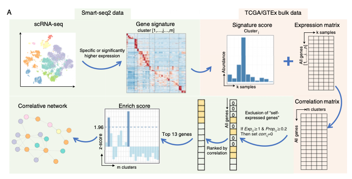

From https://linkinghub.elsevier.com/retrieve/pii/S009286742030341X

Figure S8. Analysis Framework for Correlative Cell-Cell Interaction Networks and Summary of Myeloid Cell Subsets in Human and Mouse Tumors, Related to Figure 3 and STAR Methods. (A) Workflow illustrating correlative network analysis. Cell **subtype specific genes** were identified from the Smart-seq2 scRNA-seq dataset and were used to **estimate the relative abundance in TCGA/GTEx bulk RNA-seq datasets.** After filtering the self-expressed genes, **high correlative genes** were calculated. Finally, an **enrichment analysis** based on Smart-seq2 profile was performed to **identify all correlated cell subtypes and build the correlative network** (STAR Methods).

## 3 应用场景 Application scenarios

借助scRNA-seq找到的signature genes，推断bulk RNA-seq样本的细胞类群互作网络，最后用igraph（静态）和networkD3（动态）两种网络可视化工具来展示结果。

本文档作者写了个R包scBulkCCCI，以便小伙伴运行例文的workflow。

scBulkCCCI：correlative cell-cell interaction networks based on combining scRNA-seq and TCGA datasets

- 包的自带描述文档，见ScBulkCCCI/README.md
- 示例部分数据，储存在ScBulkCCCI/data，scRNA-seq数据太大，未内置在包中，根据说明去下载；
- 数据经过预处理：数据预处理的code查看ScBulkCCCI包下ScBulkCCCI_DataPreprocess.R， 位于ScBulkCCCI/example；
- 示例运行代码ScBulkCCCI.R，于ScBulkCCCI/example；

Using signature genes identified from scRNA-seq, we inferred cell population interaction networks in bulk RNA-seq samples, and finally visualized the results using two network visualization tools: igraph (static) and networkD3 (dynamic).

The author of this document developed an R package, scBulkCCCI, to help users run the workflow described in the example.

scBulkCCCI: Correlative cell-cell interaction networks based on combining scRNA-seq and TCGA datasets

- Package documentation: See ScBulkCCCI/README.md.
- Example datasets: Stored in ScBulkCCCI/data. Note that the scRNA-seq data is too large to be included in the package—please download it separately as instructed.
- Preprocessed data: The preprocessing code can be found in ScBulkCCCI/example/ScBulkCCCI_DataPreprocess.R.
- Example execution code: ScBulkCCCI.R, located in ScBulkCCCI/example

## 4 环境设置 Environment Setup

```r
source("install_dependencies.R")
```

```
## Starting R package installation...
## ===========================================
##
## Installing CRAN packages...
## Package already installed: pheatmap
## Package already installed: RColorBrewer
## Package already installed: ggplot2
## Package already installed: ggthemes
## Package already installed: plyr
## Package already installed: dplyr
## Package already installed: stringr
## Package already installed: tibble
## Package already installed: tidyr
## Package already installed: devtools
##
## ===========================================
## Package installation completed!
## You can now run your R scripts in this directory.
```

```r
library("ScBulkCCCI")         # 单细胞与bulk数据相关性细胞互作分析｜Correlative cell-cell interaction analysis for scRNA-seq and bulk RNA-seq
library("pheatmap")           # 热图可视化｜Heatmap visualization
library("RColorBrewer")       # 调色板与配色方案｜Color palettes for plots
library("ggplot2")            # 数据可视化与绘图｜Data visualization and plotting
library("ggthemes")           # ggplot2主题美化｜Themes for ggplot2
library("plyr")               # 数据整理与分组操作｜Data manipulation and grouping
library("dplyr")              # 高效数据处理与管道操作｜Efficient data manipulation and piping
library("stringr")            # 字符串处理与正则表达式｜String manipulation and regular expressions
library("tibble")             # 增强型数据框结构｜Enhanced dataframe structure
library("tidyr")              # 数据整理与宽长格式转换｜Data tidying and reshaping
library("igraph")             # 网络分析与可视化｜Network analysis and visualization
library("networkD3")         # 动态网络可视化｜Dynamic network visualization
library("magrittr")           # 管道操作与链式编程｜Pipe operations and chaining programming

# 显示英文报错信息
# Show English error messages
Sys.setenv(LANGUAGE = "en")

# 禁止chr转成factor
# Prevent character-to-factor conversion
options(stringsAsFactors = FALSE)
```

## 5 输入文件 Input Files

输入文件包含两部分：scRNA-seq、bulk RNA-seq（以TCGA数据为例，也可以用其他RNA-seq数据）。

The input files consist of two parts: scRNA-seq and bulk RNA-seq (using TCGA data as an example, though other RNA-seq data can also be used).

### 5.1 scRNA-seq 数据 scRNA-seq data

下载地址：GSE146771

Download link: GSE146771

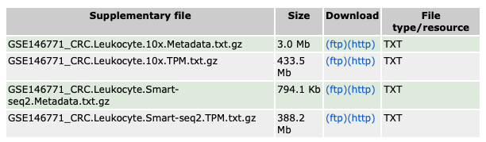

CRC.Leukocyte.Smart-seq2.Metadata.txt: 细胞类群信息

- CellName: 细胞ID
- Tissue: 细胞所属组织类型
- Global_Cluster: 一级分类
- Sub_Cluster: 二级分类

CRC.Leukocyte.Smart-seq2.TPM.txt: 细胞基因定量矩阵，列是细胞，行是基因

CRC.Leukocyte.Smart-seq2.Metadata.txt: Cell population information

- CellName: Cell ID
- Tissue: Tissue type of the cell
- Global_Cluster: First-level classification
- Sub_Cluster: Second-level classification

CRC.Leukocyte.Smart-seq2.TPM.txt: Cell gene expression matrix (columns: cells, rows: genes)

```r
## 输入ScRNAseq Smart-seq2
## Import ScRNAseq Smart-seq2
CRC_Leukocyte_SM_MD <- read.table("GSE146771_CRC.Leukocyte.Smart-seq2.Metadata.txt",header = T, sep="\t", check.names = F);dim(CRC_Leukocyte_SM_MD)
```

```
## [1] 10468    23
```

```r
# 读取TPM标准化后的单细胞表达矩阵
# Read TPM-normalized single-cell expression matrix
CRC_Leukocyte_SM_RNA <- read.table("GSE146771_CRC.Leukocyte.Smart-seq2.TPM.txt",header = T)
```

### 5.2 bulk RNAseq数据 Bulk RNA-seq Data

从UCSC Xena下载后进行预处理（COAD and READ），预处理代码见ScBulkCCCI安装包中的example/ScBulkCCCI_DataPreprocess.R。已打包到R包里，直接加载即可。

dataMerge_normal_allgene.rds: 列是样本，行是基因ID dataMerge_tumor_allgene.rds: 列是样本，行是基因ID

Preprocessed data (COAD and READ) downloaded from UCSC Xena. The preprocessing code is available in the ScBulkCCCI package under example/ScBulkCCCI_DataPreprocess.R. The processed data is bundled in the R package and can be directly loaded.

dataMerge_normal_allgene.rds: Column is sample, row is gene ID dataMerge_tumor_allgene.rds: Column is sample, row is gene ID

```r
## 获取ScBulkCCCI的安装路径
## Get the install path of ScBulkCCCI
libPath <- find.package("ScBulkCCCI")

## 导入批量表达谱
## Import bulk expression profiles
dataMerge_normal_allgene <- readRDS(paste(libPath, "/data/dataMerge_normal_allgene.rds",sep="")); dim(dataMerge_normal_allgene)
```

```
## [1] 14783   308
```

```r
dataMerge_tumor_allgene <- readRDS(paste(libPath, "/data/dataMerge_tumor_allgene.rds",sep="")); dim(dataMerge_tumor_allgene)
```

```
## [1] 13194   434
```

## 6 特征基因 Signature Genes

特征基因用于相关性互作分析

怎样筛选自己的Signature Genes？

可参考例文的“Identification of signature genes”，里面描述了接seurat的筛选标准。单细胞数据前期处理及seurat常规流程可参考FigureYa177RNAvelocity。

对于异质性较大的样品，可参考FigureYa223scNMF，不用seurat，而是借助NMF和聚类分析找marker gene。

这里直接整理例文的Table S4 of paper，已打包到R包里，直接加载即可。

CCgene_normal.rds: 正常组织富集的免疫细胞类群的signature genes；第一列基因，第二列细胞类群名

CCgene_tumor.rds: 肿瘤组织富集的免疫细胞类群的signature genes；第一列基因，第二列细胞类群名

Signature Genes were Used for Correlative Interaction Analysis

How to Select Your Own Signature Genes?

Refer to the example section “Identification of signature genes”. It describes the Seurat-based selection criteria. For single-cell data preprocessing and standard Seurat workflow, refer to FigureYa177RNAvelocity.

For highly heterogeneous samples, refer to FigureYa223scNMF. Instead of Seurat, it uses NMF and clustering to identify marker genes.

Here we directly provide the curated Table S4 of the paperTable S4 of paper, which has been packaged into the R package and can be loaded directly.

CCgene_normal.rds: Signature genes for immune cell populations enriched in normal tissues; Column 1: gene names, Column 2: cell population names

CCgene_tumor.rds: Signature genes for immune cell populations enriched in tumor tissues; Column 1: gene names, Column 2: cell population names

```r
# 从预存RDS文件中加载正常组织的细胞周期特征基因
# Load cell cycle signature genes for normal tissue from pre-saved RDS file
CCgene_normal <- readRDS(paste(libPath, "/data/CCgene_normal.rds",sep=""))

# 从预存RDS文件中加载肿瘤组织的细胞周期特征基因
# Load cell cycle signature genes for tumor tissue from pre-saved RDS file
CCgene_tumor <- readRDS(paste(libPath, "/data/CCgene_tumor.rds",sep=""))

# 查看正常组织特征基因前几行
# Preview first few rows of normal tissue signature genes
head(CCgene_normal)
```

```
##     gene          cluster
## 1  TPSD1 hM01_Mast-TPSAB1
## 2   CPA3 hM01_Mast-TPSAB1
## 3 TPSAB1 hM01_Mast-TPSAB1
## 4    HDC hM01_Mast-TPSAB1
## 5  TPSB2 hM01_Mast-TPSAB1
## 6 IL1RL1 hM01_Mast-TPSAB1
```

```r
# 查看肿瘤组织特征基因前几行
# Preview first few rows of tumor tissue signature genes
head(CCgene_tumor)
```

```
##         gene          cluster
## 1      IGLL5 hB01_PlasmaB-IgG
## 2      RAB30 hB01_PlasmaB-IgG
## 3   TNFRSF17 hB01_PlasmaB-IgG
## 4    POU2AF1 hB01_PlasmaB-IgG
## 5 ANKRD36BP2 hB01_PlasmaB-IgG
## 6      CPNE5 hB01_PlasmaB-IgG
```

## 7 相关性矩阵 Correlation matrix

基于**批量RNA测序**数据和**标记基因**评估各细胞簇的丰度

Evaluate the abundance of each cluster based on **bulk RNAseq** data and **marker genes**

```r
# 计算正常组织细胞亚型基因表达的相关性矩阵
# Calculate correlation matrix for normal tissue cell subtype gene expression
cor_matrix_normal = corMatrix(CCgene_normal,
                              cluste = "cluster",
                              dataMerge_normal_allgene)
```

```
## Doning hM01_Mast-TPSAB1
## The gene signatures of hM01_Mast-TPSAB1 :  18 ; Use 18 genes
## 308 samples in hM01_Mast-TPSAB1 abundance.
## Doning hM02_pDC-LILRA4
## The gene signatures of hM02_pDC-LILRA4 :  31 ; Use 28 genes
## 308 samples in hM02_pDC-LILRA4 abundance.
## Doning hM03_cDC2-CD1C
## The gene signatures of hM03_cDC2-CD1C :  5 ; Use 4 genes
## 308 samples in hM03_cDC2-CD1C abundance.
## Doning hM04_cDC1-BATF3
## The gene signatures of hM04_cDC1-BATF3 :  5 ; Use 5 genes
## 308 samples in hM04_cDC1-BATF3 abundance.
## Doning hM08_Macro-NLRP3
## The gene signatures of hM08_Macro-NLRP3 :  17 ; Use 17 genes
## 308 samples in hM08_Macro-NLRP3 abundance.
## Doning hM12_TAM-C1QC
## The gene signatures of hM12_TAM-C1QC :  20 ; Use 20 genes
## 308 samples in hM12_TAM-C1QC abundance.
## Doning hT04_CD4-TCF7
## The gene signatures of hT04_CD4-TCF7 :  9 ; Use 8 genes
## 308 samples in hT04_CD4-TCF7 abundance.
## Doning hT05_CD4-CXCR6
## The gene signatures of hT05_CD4-CXCR6 :  9 ; Use 9 genes
## 308 samples in hT05_CD4-CXCR6 abundance.
## Doning hT06_CD4-CXCR5
## The gene signatures of hT06_CD4-CXCR5 :  10 ; Use 10 genes
## 308 samples in hT06_CD4-CXCR5 abundance.
## Doning hT15_CD8-GZMK
## The gene signatures of hT15_CD8-GZMK :  11 ; Use 11 genes
## 308 samples in hT15_CD8-GZMK abundance.
## Doning hT16_CD8-CD6
## The gene signatures of hT16_CD8-CD6 :  17 ; Use 17 genes
## 308 samples in hT16_CD8-CD6 abundance.
## Doning hT17_CD8-CD160
## The gene signatures of hT17_CD8-CD160 :  20 ; Use 20 genes
## 308 samples in hT17_CD8-CD160 abundance.
## Doning hI02_NK-GZMK
## The gene signatures of hI02_NK-GZMK :  6 ; Use 6 genes
## 308 samples in hI02_NK-GZMK abundance.
## Doning hI04_ILC3-SLC4A10
## The gene signatures of hI04_ILC3-SLC4A10 :  10 ; Use 10 genes
## 308 samples in hI04_ILC3-SLC4A10 abundance.
## Doning hB02_GALTB-IgA
## The gene signatures of hB02_GALTB-IgA :  14 ; Use 14 genes
## 308 samples in hB02_GALTB-IgA abundance.
## Doning hB03_FollicularB-IgD
## The gene signatures of hB03_FollicularB-IgD :  12 ; Use 12 genes
## 308 samples in hB03_FollicularB-IgD abundance.
## Doning hB05_GCBCell-LRMP
## The gene signatures of hB05_GCBCell-LRMP :  11 ; Use 11 genes
## 308 samples in hB05_GCBCell-LRMP abundance.
```

```r
# 显示相关性矩阵维度
# Show correlation matrix dimensions
dim(cor_matrix_normal)
```

```
## [1] 14783    17
```

```r
# 计算肿瘤组织细胞亚型基因表达的相关性矩阵
# Calculate correlation matrix for tumor tissue cell subtype gene expression
cor_matrix_tumor = corMatrix(CCgene_tumor,
                             cluste = "cluster",
                             dataMerge_tumor_allgene)
```

```
## Doning hB01_PlasmaB-IgG
## The gene signatures of hB01_PlasmaB-IgG :  7 ; Use 5 genes
## 434 samples in hB01_PlasmaB-IgG abundance.
## Doning hI02_NK-GZMK
## The gene signatures of hI02_NK-GZMK :  6 ; Use 6 genes
## 434 samples in hI02_NK-GZMK abundance.
## Doning hI04_ILC3-SLC4A10
## The gene signatures of hI04_ILC3-SLC4A10 :  10 ; Use 9 genes
## 434 samples in hI04_ILC3-SLC4A10 abundance.
## Doning hE01_Endothelium-CDH5
## The gene signatures of hE01_Endothelium-CDH5 :  18 ; Use 15 genes
## 434 samples in hE01_Endothelium-CDH5 abundance.
## Doning hF01_Myofib-ACTA2
## The gene signatures of hF01_Myofib-ACTA2 :  25 ; Use 25 genes
## 434 samples in hF01_Myofib-ACTA2 abundance.
## Doning hF02_CAF-FAP
## The gene signatures of hF02_CAF-FAP :  21 ; Use 21 genes
## 434 samples in hF02_CAF-FAP abundance.
## Doning hM01_Mast-TPSAB1
## The gene signatures of hM01_Mast-TPSAB1 :  18 ; Use 17 genes
## 434 samples in hM01_Mast-TPSAB1 abundance.
## Doning hM02_pDC-LILRA4
## The gene signatures of hM02_pDC-LILRA4 :  31 ; Use 26 genes
## 434 samples in hM02_pDC-LILRA4 abundance.
## Doning hM03_cDC2-CD1C
## The gene signatures of hM03_cDC2-CD1C :  5 ; Use 4 genes
## 434 samples in hM03_cDC2-CD1C abundance.
## Doning hM04_cDC1-BATF3
## The gene signatures of hM04_cDC1-BATF3 :  5 ; Use 5 genes
## 434 samples in hM04_cDC1-BATF3 abundance.
## Doning hM08_Macro-NLRP3
## The gene signatures of hM08_Macro-NLRP3 :  17 ; Use 15 genes
## 434 samples in hM08_Macro-NLRP3 abundance.
## Doning hM12_TAM-C1QC
## The gene signatures of hM12_TAM-C1QC :  17 ; Use 17 genes
## 434 samples in hM12_TAM-C1QC abundance.
## Doning hM13_TAM-SPP1
## The gene signatures of hM13_TAM-SPP1 :  15 ; Use 15 genes
## 434 samples in hM13_TAM-SPP1 abundance.
## Doning hT04_CD4-TCF7
```

[output cut: 11 more lines]

```
## Doning hT09_CD4-CXCL13
## The gene signatures of hT09_CD4-CXCL13 :  12 ; Use 12 genes
## 434 samples in hT09_CD4-CXCL13 abundance.
## Doning hT11_CD4-CTLA4
## The gene signatures of hT11_CD4-CTLA4 :  19 ; Use 19 genes
## 434 samples in hT11_CD4-CTLA4 abundance.
## Doning hT15_CD8-GZMK
## The gene signatures of hT15_CD8-GZMK :  11 ; Use 11 genes
## 434 samples in hT15_CD8-GZMK abundance.
## Doning hT16_CD8-CD6
## The gene signatures of hT16_CD8-CD6 :  17 ; Use 17 genes
## 434 samples in hT16_CD8-CD6 abundance.
## Doning hT18_CD8-LAYN
## The gene signatures of hT18_CD8-LAYN :  22 ; Use 22 genes
## 434 samples in hT18_CD8-LAYN abundance.
```

```r
# 显示相关性矩阵维度
# Show correlation matrix dimensions
dim(cor_matrix_tumor)
```

```
## [1] 13194    22
```

## 8 富集分析 Enrichment analysis

### 8.1 高相关性基因 - 针对特定细胞亚型与其他细胞亚型 Highly correlated genes - For a specific cell subtype and another cell subtype

分析成果：从调整后的相关性矩阵中获得的、特定细胞亚型与其他亚型的非自身表达基因的排序相关性结果

步骤1：鉴定自身表达基因

步骤2：通过自身表达基因调整相关性矩阵

Achievement: the ranked correlated non-self-expressed genes from the adjusted correlation matrix for a specific cell subtype

step 1. Identify self-expressed genes

step 2. Adjust correlation matrix by self-expressed genes

```r
# 从正常组织特征基因中提取唯一的亚群名称列表，并选择第一个亚群
# Extract unique subcluster names from normal tissue signature genes and select the first one
subcluter_name= unique(CCgene_normal$cluster)[1] #unique(CCgene_normal$cluster)[1] #unique(CCgene_normal$cluster)[1]

# 筛选与指定亚群高度相关且非自身表达的基因
# Filter genes highly correlated with target subcluster but not self-expressed
highCorNonSelfGenes <- highCorGene(subcluter_name= subcluter_name,
                                  Sub_Cluster="Sub_Cluster", CellName="CellName",
                                  cellMetaData= CRC_Leukocyte_SM_MD, ScExMatrix=CRC_Leukocyte_SM_RNA,
                                  cor_matrix=cor_matrix_normal,TopMethod="Positive")
```

```
## The number of self-expressed genes: 6806 ; Other genes: 8373
```

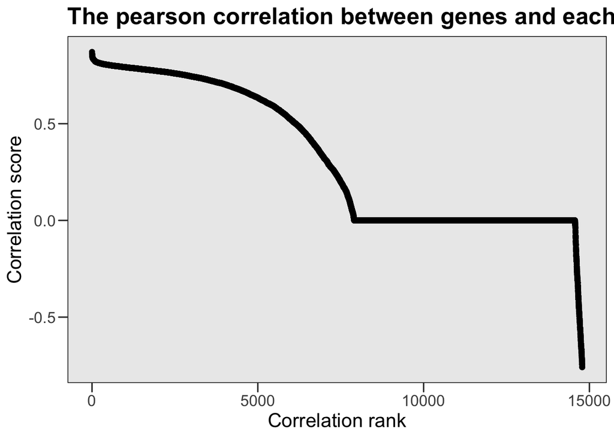

```r
# 绘制相关性排名图
# Plot correlation rank
highCorNonSelfGenes$correlatioRankPlot
```

### 8.2 富集评分 - 针对特定细胞亚型与多个细胞亚型 Enrich score - For a specific cell subtype and multiple cell subtype

```r
# 合并正常和肿瘤组织的所有独特亚群名称
# Combine all unique subcluster names from normal and tumor tissues
allClusters <- unique(c(as.character(CCgene_normal$cluster), as.character(CCgene_tumor$cluster)))
#allClusters<- unique(CRC_Leukocyte_SM_MD$Sub_Cluster)

# 执行一对多亚群富集分析（使用前13个高相关基因）
# Perform one-to-multiple subcluster enrichment analysis (using top 13 correlated genes)
ES <- oneToMultiple(allClusters= allClusters,
                   topCorGene=names(highCorNonSelfGenes$CorGeneRank[1:13]),
                   cellMetaData= CRC_Leukocyte_SM_MD, ScExMatrix=CRC_Leukocyte_SM_RNA,
                   Sub_Cluster="Sub_Cluster", CellName="CellName")
scale(na.omit(ES))
```

```
##                            [,1]
## hM01_Mast-TPSAB1     -1.9799987
## hM02_pDC-LILRA4      -0.5584519
## hM03_cDC2-CD1C       -1.1000895
## hM04_cDC1-BATF3      -1.4713680
## hM08_Macro-NLRP3     -0.8910390
## hM12_TAM-C1QC         0.1887561
## hT04_CD4-TCF7         1.2831095
## hT05_CD4-CXCR6        1.1929408
## hT06_CD4-CXCR5        0.8539938
## hT15_CD8-GZMK         0.6653809
## hT16_CD8-CD6          0.4304935
## hT17_CD8-CD160       -0.1142279
## hI02_NK-GZMK          0.1600125
## hI04_ILC3-SLC4A10    -0.5510111
## hB02_GALTB-IgA       -0.8152342
## hB03_FollicularB-IgD -0.1908387
## hB05_GCBCell-LRMP    -1.2249442
## hB01_PlasmaB-IgG     -0.7380180
## hF01_Myofib-ACTA2     1.2923418
## hF02_CAF-FAP          2.2330830
## hM13_TAM-SPP1        -0.5570324
## hT07_CD4-GZMK         0.9681913
## hT08_CD4-IL23R        0.8636395
## hT09_CD4-CXCL13       0.5244282
## hT11_CD4-CTLA4       -0.1464454
## hT18_CD8-LAYN        -0.3176723
## attr(,"scaled:center")
## [1] -0.1565238
## attr(,"scaled:scale")
## [1] 0.2085188
```

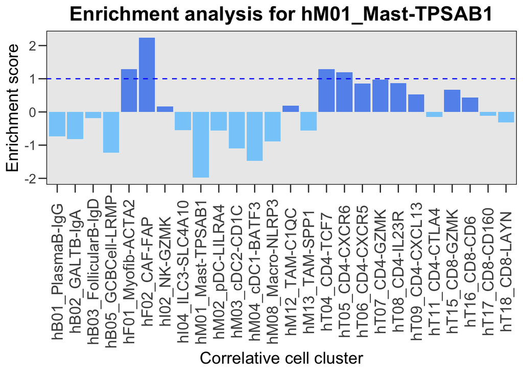

```r
# 创建绘图数据框（包含标准化分数和颜色分组信息）
# Create plotting dataframe (with normalized scores and color groups)
ESData = data.frame(name = rownames(scale(na.omit(ES))),ES=scale(na.omit(ES)))
ESData$colorInfo = as.factor(ifelse(ESData$ES>0, "pos", "neg"))

# 富集分数可视化
# Enrichment Score Visualization
ggplot() + geom_bar(data = ESData,aes(x=name, y=ES, fill=colorInfo),stat = "identity") +
  geom_hline(yintercept=1, color="blue", linetype="dashed") +
  scale_fill_manual(values=c("#87CEFA", "#6495ED")) +
  labs(x = "Correlative cell cluster", y = "Enrichment score", title = paste("Enrichment analysis for",subcluter_name,sep = " ")) +
  theme_base() +
  theme(axis.text.x = element_text(size = 15, vjust = 0.5, hjust = 0.5, angle = 90)) +
  theme(legend.position="none") +
  theme(plot.title = element_text(hjust = 0.5))
```

```r
# 保存为PDF
# Save as PDF
ggsave("EnrichScore.pdf", width = 12, height = 8)
```

### 8.3 相关性网络分析 - 针对多细胞亚型间互作 Correlative network - For multiple cell subtypes and multiple cell subtypes

```r
# 合并正常和肿瘤组织的所有独特亚群名称
# Combine all unique subcluster names from normal and tumor tissues
allClusters = unique(c(as.character(CCgene_normal$cluster), as.character(CCgene_tumor$cluster))) #unique(CRC_Leukocyte_SM_MD$Sub_Cluster)

# 例文选了top 13 highly correlated non-self-expressed genes were selected from the adjusted correlation matrix.
# 根据自己的数据调整
# The reference selected top 13 highly correlated non-self-expressed genes from the adjusted correlation matrix.
# Adjust parameters according to your own data
topGeneNum <- 13

{
  # 正常组织亚群相互作用分析
  # Normal tissue subcluster interaction analysis
  normal_subtype_ES = cellCellInteraction(specificSubtypes = unique(CCgene_normal$cluster),
                                          allClusters = allClusters, # unique(c(CCgene_normal$cluster, CCgene_tumor$cluster)), #unique(CRC_Leukocyte_SM_MD$Sub_Cluster)
                                          cor_matrix = cor_matrix_normal,
                                          cellMetaData= CRC_Leukocyte_SM_MD,
                                          ScExMatrix=CRC_Leukocyte_SM_RNA,
                                          Sub_Cluster="Sub_Cluster",
                                          CellName="CellName",
                                          topGeneNum = topGeneNum,
                                          TopMethod="Positive")

  # 肿瘤组织亚群相互作用分析
  # Tumor tissue subcluster interaction analysis
  tumor_subtype_ES = cellCellInteraction(specificSubtypes = unique(CCgene_tumor$cluster),
                                         allClusters = allClusters, # unique(c(CCgene_normal$cluster, CCgene_tumor$cluster)),
                                         cor_matrix = cor_matrix_tumor,
                                         cellMetaData= CRC_Leukocyte_SM_MD,
                                         ScExMatrix=CRC_Leukocyte_SM_RNA,
                                         Sub_Cluster="Sub_Cluster",
                                         CellName="CellName",
                                         topGeneNum = topGeneNum,
                                         TopMethod="Positive")
}
```

```
## A specific cell subtype hM01_Mast-TPSAB1
## The number of self-expressed genes: 6806 ; Other genes: 8373
## A specific cell subtype hM02_pDC-LILRA4
## The number of self-expressed genes: 7201 ; Other genes: 7978
## A specific cell subtype hM03_cDC2-CD1C
## The number of self-expressed genes: 7894 ; Other genes: 7285
## A specific cell subtype hM04_cDC1-BATF3
## The number of self-expressed genes: 7652 ; Other genes: 7527
## A specific cell subtype hM08_Macro-NLRP3
## The number of self-expressed genes: 5189 ; Other genes: 9990
## A specific cell subtype hM12_TAM-C1QC
## The number of self-expressed genes: 7501 ; Other genes: 7678
## A specific cell subtype hT04_CD4-TCF7
## The number of self-expressed genes: 6027 ; Other genes: 9152
## A specific cell subtype hT05_CD4-CXCR6
## The number of self-expressed genes: 5930 ; Other genes: 9249
## A specific cell subtype hT06_CD4-CXCR5
## The number of self-expressed genes: 6388 ; Other genes: 8791
## A specific cell subtype hT15_CD8-GZMK
## The number of self-expressed genes: 5998 ; Other genes: 9181
## A specific cell subtype hT16_CD8-CD6
## The number of self-expressed genes: 6548 ; Other genes: 8631
## A specific cell subtype hT17_CD8-CD160
## The number of self-expressed genes: 6454 ; Other genes: 8725
## A specific cell subtype hI02_NK-GZMK
## The number of self-expressed genes: 6005 ; Other genes: 9174
## A specific cell subtype hI04_ILC3-SLC4A10
## The number of self-expressed genes: 6661 ; Other genes: 8518
## A specific cell subtype hB02_GALTB-IgA
## The number of self-expressed genes: 5638 ; Other genes: 9541
## A specific cell subtype hB03_FollicularB-IgD
## The number of self-expressed genes: 6021 ; Other genes: 9158
## A specific cell subtype hB05_GCBCell-LRMP
## The number of self-expressed genes: 8277 ; Other genes: 6902
## A specific cell subtype hB01_PlasmaB-IgG
## The number of self-expressed genes: 5506 ; Other genes: 9673
## A specific cell subtype hI02_NK-GZMK
## The number of self-expressed genes: 6005 ; Other genes: 9174
## A specific cell subtype hI04_ILC3-SLC4A10
## The number of self-expressed genes: 6661 ; Other genes: 8518
```

[output cut: 23 more lines]

```
## The number of self-expressed genes: 5930 ; Other genes: 9249
## A specific cell subtype hT07_CD4-GZMK
## The number of self-expressed genes: 5753 ; Other genes: 9426
## A specific cell subtype hT08_CD4-IL23R
## The number of self-expressed genes: 6415 ; Other genes: 8764
## A specific cell subtype hT09_CD4-CXCL13
## The number of self-expressed genes: 6154 ; Other genes: 9025
## A specific cell subtype hT11_CD4-CTLA4
## The number of self-expressed genes: 6677 ; Other genes: 8502
## A specific cell subtype hT15_CD8-GZMK
## The number of self-expressed genes: 5998 ; Other genes: 9181
## A specific cell subtype hT16_CD8-CD6
## The number of self-expressed genes: 6548 ; Other genes: 8631
## A specific cell subtype hT18_CD8-LAYN
## The number of self-expressed genes: 6709 ; Other genes: 8470
```

```r
# 添加组织来源标签
# Add tissue origin labels
normal_subtype_ES$tissue = "normal"
tumor_subtype_ES$tissue = "tumor"

# 合并正常和肿瘤结果
# Merge normal and tumor results
subtype_ES <- rbind(normal_subtype_ES,tumor_subtype_ES)

# 保存肿瘤特异相互作用结果
# Save tumor-specific interaction results
write.table(tumor_subtype_ES, file = "output_tumor_subtype.Correlative.cell_cell.interactions.txt", quote = F, row.names = F, sep = "\t") #

# 保存合并后的相互作用结果
# Save merged interaction results
write.table(subtype_ES, file = "output_correlative.cell_cell.interactions.txt", quote = F, row.names = F, sep = "\t")
```

### 8.4 比较ScBulkCCCI与原文的相关细胞相互作用结果 Compare the result of correlative cell cell interactions between ScBulkCCCI and paper.

```r
# 筛选hM03开头的亚群且富集分数>1的相互作用
# Filter interactions for hM03-prefixed subtypes with enrichment score >1
dplyr::filter(subtype_ES, grepl("^hM03", specificSubtype), EnrichScore>1)
```

```
##    specificSubtype    otherSubtype EnrichScore tissue
## 1   hM03_cDC2-CD1C   hT15_CD8-GZMK    1.058939 normal
## 2   hM03_cDC2-CD1C    hT16_CD8-CD6    1.037520 normal
## 3   hM03_cDC2-CD1C  hT17_CD8-CD160    1.034677 normal
## 4   hM03_cDC2-CD1C   hT07_CD4-GZMK    1.126742 normal
## 5   hM03_cDC2-CD1C  hT08_CD4-IL23R    1.152026 normal
## 6   hM03_cDC2-CD1C hT09_CD4-CXCL13    1.085530 normal
## 7   hM03_cDC2-CD1C  hT11_CD4-CTLA4    1.495109 normal
## 8   hM03_cDC2-CD1C   hT18_CD8-LAYN    1.312396 normal
## 9   hM03_cDC2-CD1C   hT04_CD4-TCF7    1.974185  tumor
## 10  hM03_cDC2-CD1C  hT05_CD4-CXCR6    1.585644  tumor
## 11  hM03_cDC2-CD1C  hT06_CD4-CXCR5    1.661717  tumor
## 12  hM03_cDC2-CD1C  hT08_CD4-IL23R    1.492683  tumor
## 13  hM03_cDC2-CD1C hT09_CD4-CXCL13    1.075055  tumor
## 14  hM03_cDC2-CD1C  hT11_CD4-CTLA4    1.352626  tumor
```

```r
# 筛选hM04开头的亚群且富集分数>1的相互作用
# Filter interactions for hM04-prefixed subtypes with enrichment score >1
dplyr::filter(subtype_ES, grepl("^hM04", specificSubtype), EnrichScore>1)
```

```
##    specificSubtype         otherSubtype EnrichScore tissue
## 1  hM04_cDC1-BATF3 hB03_FollicularB-IgD    2.180397 normal
## 2  hM04_cDC1-BATF3    hB05_GCBCell-LRMP    1.990123 normal
## 3  hM04_cDC1-BATF3     hB01_PlasmaB-IgG    2.040281 normal
## 4  hM04_cDC1-BATF3        hT04_CD4-TCF7    1.040411  tumor
## 5  hM04_cDC1-BATF3       hT06_CD4-CXCR5    1.222859  tumor
## 6  hM04_cDC1-BATF3         hT16_CD8-CD6    1.039920  tumor
## 7  hM04_cDC1-BATF3       hT17_CD8-CD160    1.014095  tumor
## 8  hM04_cDC1-BATF3       hT08_CD4-IL23R    1.190450  tumor
## 9  hM04_cDC1-BATF3      hT09_CD4-CXCL13    1.212595  tumor
## 10 hM04_cDC1-BATF3       hT11_CD4-CTLA4    1.346137  tumor
## 11 hM04_cDC1-BATF3        hT18_CD8-LAYN    1.135429  tumor
```

```r
# 筛选hM12开头的亚群且富集分数>1的相互作用
# Filter interactions for hM12-prefixed subtypes with enrichment score >1
dplyr::filter(subtype_ES, grepl("^hM12", specificSubtype), EnrichScore>1)
```

```
##   specificSubtype         otherSubtype EnrichScore tissue
## 1   hM12_TAM-C1QC hB03_FollicularB-IgD    2.403275 normal
## 2   hM12_TAM-C1QC    hB05_GCBCell-LRMP    1.700508 normal
## 3   hM12_TAM-C1QC       hT08_CD4-IL23R    2.209894 normal
## 4   hM12_TAM-C1QC     hM01_Mast-TPSAB1    1.077847  tumor
## 5   hM12_TAM-C1QC        hT04_CD4-TCF7    1.230984  tumor
## 6   hM12_TAM-C1QC      hT09_CD4-CXCL13    1.198266  tumor
## 7   hM12_TAM-C1QC        hT18_CD8-LAYN    1.595276  tumor
```

```r
# 筛选hM13开头的亚群且富集分数>1的相互作用
# Filter interactions for hM13-prefixed subtypes with enrichment score >1
dplyr::filter(subtype_ES, grepl("^hM13", specificSubtype), EnrichScore>1)
```

```
##   specificSubtype      otherSubtype EnrichScore tissue
## 1   hM13_TAM-SPP1 hF01_Myofib-ACTA2    2.518859  tumor
## 2   hM13_TAM-SPP1      hF02_CAF-FAP    4.083852  tumor
```

> hM13_TAM-SPP1的富集分析结果在ScBulkCCCI中与文献报道一致。 The enrichment analysis result of `hM13_TAM-SPP1` from ScBulkCCCI is the same result as paper show.
- - 此外，hM03、hM04或hM12的富集分析结果并不完全相同，但具有相似性。
- - What’s more, the enrichment analysis results of hM03, hM04 or hM12 are not identical, but they are similar.

## 9 开始画图 Plotting

```r
# 读取肿瘤亚群间相互作用结果文件
# Read tumor subtype interaction results file
tumor_subtype_ES <- read.table("output_tumor_subtype.Correlative.cell_cell.interactions.txt", header = T, sep = "\t")

# 筛选显著相互作用（EnrichScore > 1.96，相当于p<0.05）
# Filter significant interactions (EnrichScore > 1.96, approx. p<0.05)
networkData <- dplyr::filter(tumor_subtype_ES, EnrichScore>1.96, specificSubtype != otherSubtype)

# 重新加载单细胞元数据
# Reload single-cell metadata
CRC_Leukocyte_SM_MD <- read.table(paste(libPath, "/data/CRC.Leukocyte.Smart-seq2.Metadata.txt",sep=""),header = T, sep="\t", check.names = F);dim(CRC_Leukocyte_SM_MD)
```

```
## [1] 10468    23
```

```r
# 获取网络数据与元数据中的共同亚群
# Get overlapping subtypes between network and metadata
overlap <- intersect(unique(c(networkData$specificSubtype,networkData$otherSubtype)), CRC_Leukocyte_SM_MD$Sub_Cluster)

# 从元数据中提取节点信息
# Extract node information from metadata
nodes <- dplyr::filter(CRC_Leukocyte_SM_MD,Sub_Cluster %in% overlap) %>%
  select(Sub_Cluster, Global_Cluster) %>%
  dplyr::distinct(Sub_Cluster,Global_Cluster)

# 构建完整节点列表
# Build complete node list
nodes <- merge(data.frame(node = unique(c(networkData$specificSubtype,networkData$otherSubtype))), nodes, by.x="node", by.y="Sub_Cluster", all = T)
nodes[is.na(nodes)] ="Not annotation"
```

下面分别用igraph（静态）和networkD3（动态）两种网络可视化工具来展示Enrichment analysis结果。

Below we present the Enrichment analysis results visualized using two network tools: igraph (static) and networkD3 (interactive).

### 9.1 通过igraph绘制网络 Plot network by igraph

```r
# 从数据框创建无向图对象
# Create undirected graph object from data frame
g <- graph_from_data_frame(networkData, directed=F, vertices=nodes)

# 设置节点标签大小（0.75倍默认大小）
# Set vertex label size (0.75x default)
V(g)$label.cex=0.75

# 设置节点标签颜色为黑色
# Set vertex label color to black
V(g)$label.color <- "black"

# 使用RColorBrewer的Paired调色板设置节点颜色
# Set vertex colors using RColorBrewer's Paired palette
V(g)$color <- brewer.pal(n = 12, name ="Paired")[as.numeric(as.factor(V(g)$Global_Cluster))]

# 设置节点边框颜色为白色
# Set vertex frame color to white
V(g)$frame.color <- "white"


# 创建PDF输出文件
# Create PDF output file
pdf("network_igraph.pdf")

# 绘制网络图
# Plot network graph
plot(g)

# 添加图例
# Add legend
legend(x=-1.5, y= 1, unique(as.factor(V(g)$Global_Cluster)), pch=21,
       col="#777777", pt.bg=unique(brewer.pal(n = 12, name ="Paired")[as.numeric(as.factor(V(g)$Global_Cluster))]),
       pt.cex=2, cex=.8, bty="n", ncol=1)

# 关闭图形设备
# Close graphics device
dev.off()
```

[figure not shown]

### 9.2 绘制动态网络 Plot dynamic network

```r
# 创建节点属性数据框
# Create node attributes dataframe
nodeData <- data.frame(name=nodes$node,
                       group= as.factor(nodes$Global_Cluster))

# 创建边列表数据框
# Create edge list dataframe
linkData <- data.frame(source = (match(networkData$specificSubtype, nodeData$name)-1),
                       target = (match(networkData$otherSubtype, nodeData$name)-1))

# 交互式网络绘制
# Interactive Network Visualization
forceNetwork(
  Links = linkData,
  Nodes = nodeData,
  Source = "source",
  Target = "target",
  NodeID = "name",Group = "group", legend = T, opacityNoHover = 1,zoom=T)
```

[interactive chart not shown]

```r
# 输出到网页文件
# Output to a web page file
forceNetwork(
  Links = linkData,
  Nodes = nodeData,
  Source = "source",
  Target = "target",
  NodeID = "name",Group = "group", legend = T, opacityNoHover = 1,zoom=T) %>%
  saveNetwork(file = 'network.html')
```

打开`network.html`文件，即可查看动态网络。

Open the ‘network.html’ file and you can view the dynamic network.

## 10 附：Cell type enrichment across tissues

## 11 Attached: Cell type enrichment across tissues

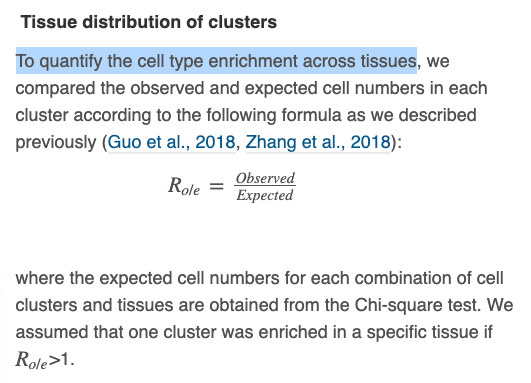

```r
CRC_Leukocyte_10x_MD <- read.table(paste(libPath, "/data/CRC.Leukocyte.10x.Metadata.txt",sep=""),header = T, sep="\t", check.names = F);dim(CRC_Leukocyte_10x_MD)
```

```
## [1] 43817    23
```

```r
CRC_Leukocyte_10x_MD_FIilter = dplyr::filter(CRC_Leukocyte_10x_MD, grepl("^hM",Sub_Cluster))

Roe <- calTissueDist(CRC_Leukocyte_10x_MD_FIilter,colname.cluster="Sub_Cluster", colname.tissue="Tissue")
pheatmap::pheatmap(Roe, cluster_rows = F, cluster_cols = F,
                   color = colorRampPalette(brewer.pal(n = 7, name ="YlOrRd"))(50),
                   display_numbers = TRUE,number_color = "black")
```

[output not shown]